# Challenge

In this challenge, you will be building a model of a *galvanometer,* which is an instrument used to measure voltages and other quantities that can be *represented* by voltages. Here is a video of how a galvanometer is constructed and how it works.

```matlab
%%html
<iframe width="900" height="540" src="https://www.youtube.com/embed/_kLvQpKuyWs" frameborder="0" allow="accelerometer; autoplay; encrypted-media; gyroscope; picture-in-picture" allowfullscreen></iframe>
```

[video not shown]

This device converts electrical power (albeit small amounts) into mechanical power to move the indicator needle against a torsional spring. This requires electrical-mechanical transduction of power, like a motor, but where a motor can spin its rotational inertia freely, the galvanometer moves against a *torsional spring*, which stores potential energy. We haven't talked about springs *at all* this semester, so we'll need to lay down some quality thermodynamic assumptions about springs, and talk about how they store energy. This will allow us to use them when building a model of the galvanometer.

## Mechanical Springs

Mechanical springs come in all shapes and sizes. If the spring is *linear*, which many are (at least for small values of spring deflection), it follows *Hooke's Law*, which states that there is a linear relationship between force (for a translational spring) or torque (for a torsional spring) and the spring's deflection.

A diagram representing an "ideal" spring, which has negligible mass and dissipates negligible heat to the environment when it is deformed, is often drawn as follows. Both a torsional (rotational) spring and a translational spring are represented in the diagram below.

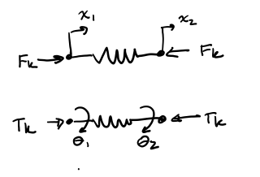

As drawn, Hooke's Law can be written for the translational spring as:

$$F_k = K(x_1-x_2) = Kx_{12}$$

If you imagine the scenario in which $x_{12}>0$, or $x_1>x_2$, it is clear that the spring would be in compression as shown. If the sign of $x_{12}$ were to flip, Hooke's Law would predict a negative force, meaning that the spring would be in tension with $F_k$ pointing outwards from each end. For a translational spring, spring constant "K" can be represented in SI units of $\frac{N}{m}$.

The expression of Hooke's Law for a torsional spring is similar:

$$T_k = K(\theta_1 - \theta_2) = K\theta_{12}$$

For a torsional spring, the spring constant $K$ can be expressed in base SI units of $\frac{Nm}{rad}$.

The picture above shows a free-body diagram on each type of spring. If a spring's mass is negligible, Newton's second law for the spring indicates that the force on each end of the spring must be an equal $F_k$ for a translational spring, and $T_k$ for a torsional spring.

From an energetic perspective, if a spring is considered massless, it ONLY stores elastic potential energy, and stores no kinetic energy. If it is also assumed that the spring does not, by itself, dissipate significant energy across the system boundaries through heat transfer, then the first law tells us that any work done on the spring will cause it to store potential energy.

$$\require{cancel}$$$$E = W_{net} + \cancel{Q_{net}}$$

because mechanical work is $F\cdot x$ for a translational system and $T\cdot \theta$ for a rotational system, the spring's energy storage can be expressed for a translational spring as: $$\require{cancel}$$ $$E = W_{net} + \cancel{Q_{net}} = \int F_k dx_{12} = \frac{1}{2} K x_{12}^2$$ Similarly, for a torsional spring, we can write: $$E = W_{net} + \cancel{Q_{net}} = \int F_k d\theta_{12} = \frac{1}{2} K \theta_{12}^2$$

These equations represent the stored *Elastic Potential Energy* in the spring. However, the issue with both of these forms of the energy storage equation for springs is that they don't include a *power variable*. This means that writing the first law of thermodynamics for the spring in *power* form doesn't produce a clean statement about power variables. Without a direct statement about how the spring's power variables interact, applying continuity and compatibility equations to a mechanical system with a spring would be difficult.

for this reason, the energy in a translational spring is often re-written as:

$$E = \frac{1}{2K} F_k^2$$

and for a torsional spring as:

$$E = \frac{1}{2K} T_k^2$$

A quick algebraic substitution of $F_k= K x_{12}$ for the translational spring or $T_k = K \theta_{12}$ for the torsional spring will show that the two types of expressions for stored energy are equivalent.

Th expression for stored spring energy in terms of *power variables* shows us that unlike a mass, which stores kinetic energy by accumulating the *across* type power variables $v$ or $\Omega$, a spring stores energy by accumulating the *through* type power variables $F$ or $T$. For this reason, springs are often called "Through Type" energy storage elements.

Using the power-variable form of the energy storage equation, we can write the first law of thermodynamics in power form for a translational spring as:

$$\dot{E} = \frac{1}{K} F_k \dot{F}_k = \dot{W}_{in}-\dot{W}_{out} = F_k v_{12}$$

and for a torsional spring, we find a similar relationship:

$$\dot{E} = \frac{1}{K} T_k \dot{T}_k = \dot{W}_{in}-\dot{W}_{out} = T_k \Omega_{12}$$

Cancelling the extra appearance of the through-type variables in each of these equations, we find that for a translational spring, we have:

$$\dot{F}_k = Kv_{12}$$

and for a torsional spring, we have:

$$\dot{T}_k = K\Omega_{12}$$

Where "1" and "2" represent the two "ends" of each spring. With these equations, springs are easy to include in equivalent-circuit representations of mechanical systems.